# Styling Scatterplots

##### *Note*

- - If you do not like the default colors in the ggplot2, there are a couple of ways to change that.The **RColorBrewer**package will definitely help. If you want to know more about **RColorBrewer** package,see [here](https://ggplot2.tidyverse.org/reference/scale_brewer.html). Additionally,the **viridis** package is also very helpful to change the default colors. For more information of the **viridis** package, check [here](https://cran.r-project.org/web/packages/viridis/vignettes/intro-to-viridis.html).
  - If you do not like all the options that the **RColorBrewer** and **viridis** packages provide, see [here](http://www.sthda.com/english/wiki/ggplot2-colors-how-to-change-colors-automatically-and-manually) to work with color in the **ggplot2** package.

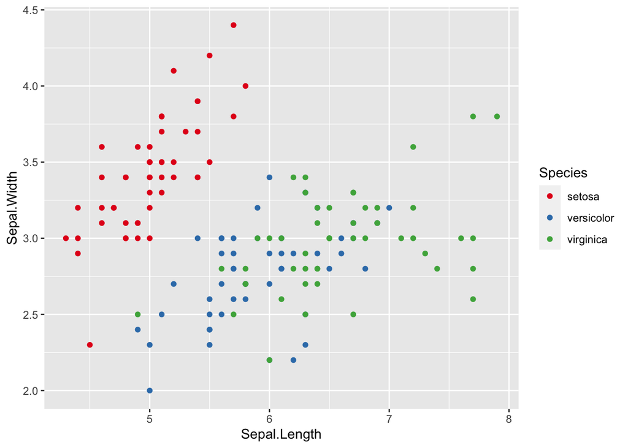

```r
ggplot(data = iris, aes(x=Sepal.Length, y=Sepal.Width, color=Species))+
  geom_point()+
  ## Where RColorBrewer package comes in
  scale_colour_brewer(palette = "Set1") ## There are more options available for palette
```

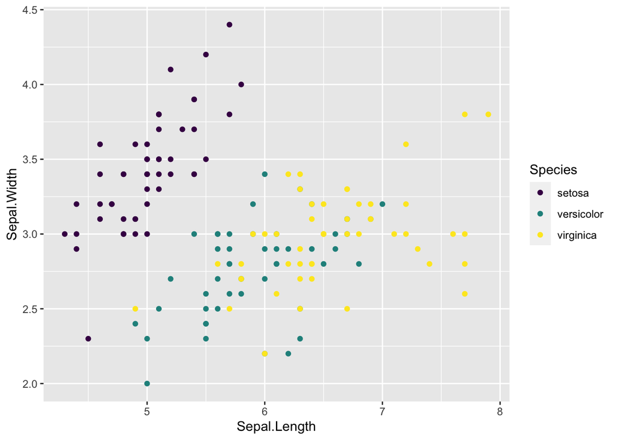

```r
ggplot(data = iris, aes(x=Sepal.Length, y=Sepal.Width, color=Species))+
  geom_point()+
  ## Where viridis package comes in
  scale_color_viridis(discrete=TRUE,option = "D")  ## There are more options to choose
```

#### **Transparency**

- We can always distinguish the `Species` by `transparency`.

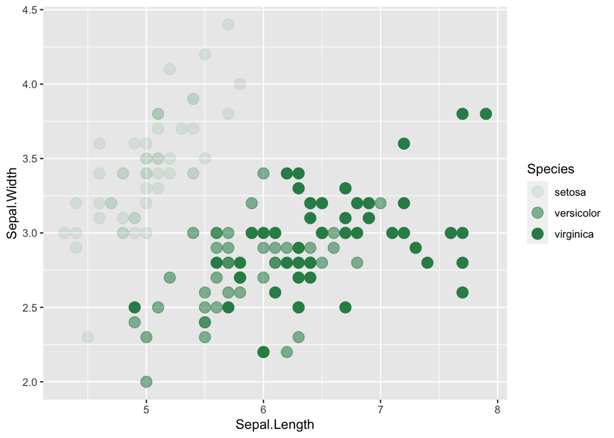

```r
ggplot(iris, aes(x=Sepal.Length, y=Sepal.Width,
                 ## Where transparency comes in
                 alpha=Species)) +
    geom_point(size =4, color="seagreen")
```

#### **Shape**

- `Shape` is also a common way to help us to see relationship between two variables within different groups.

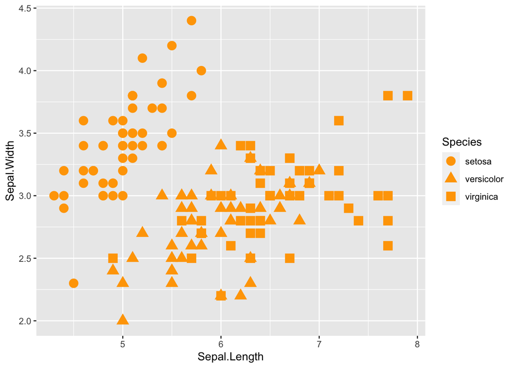

```r
ggplot(iris, aes(x=Sepal.Length, y=Sepal.Width,
                 ## Where shape comes in
                 shape=Species)) +
    geom_point(size = 4,color="orange")
```

#### **Size**

- Furthermore, `size` is a great option that we can take a look at as well.
- However, note that `size` will work better with continuous variables.

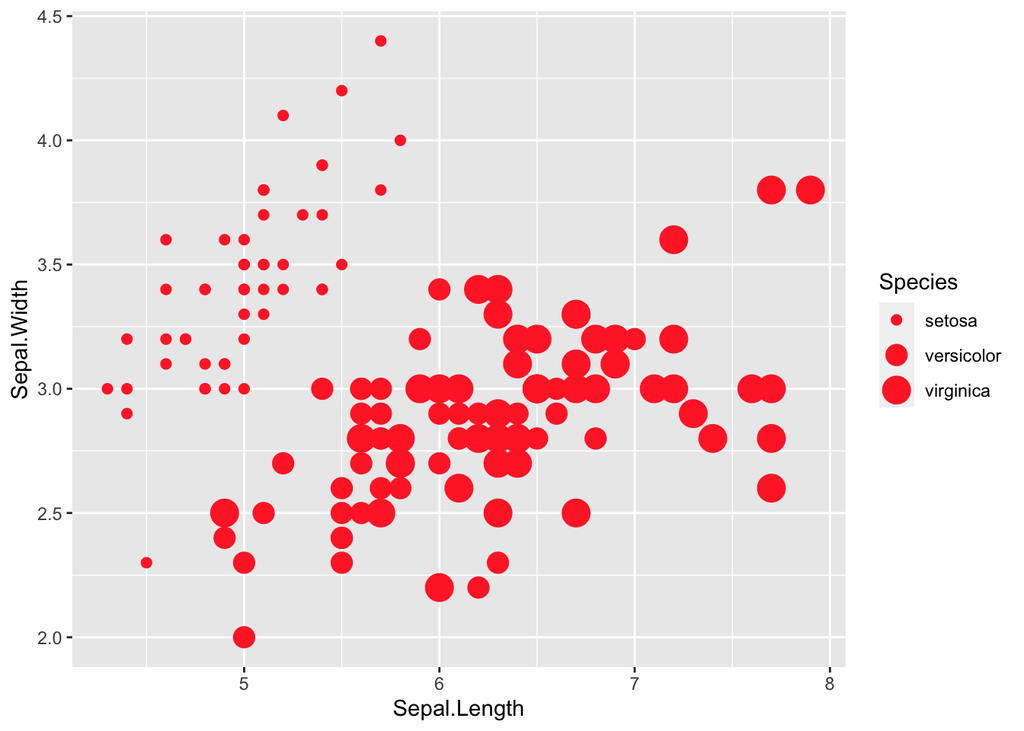

```r
ggplot(iris, aes(x=Sepal.Length, y=Sepal.Width,
                 ## Where size comes in
                 size=Species)) +
    geom_point(color="firebrick1")
```

***

#### **Put all the options together**

- Of course, we can always mix `color`,`transparency`,`shape` and `size` together to get prettier plot.
- Personally, mixing more than two can make your graph a little bit messy, choosing to mix two seems to be a nice choice. However, do whatever you perfer!!!

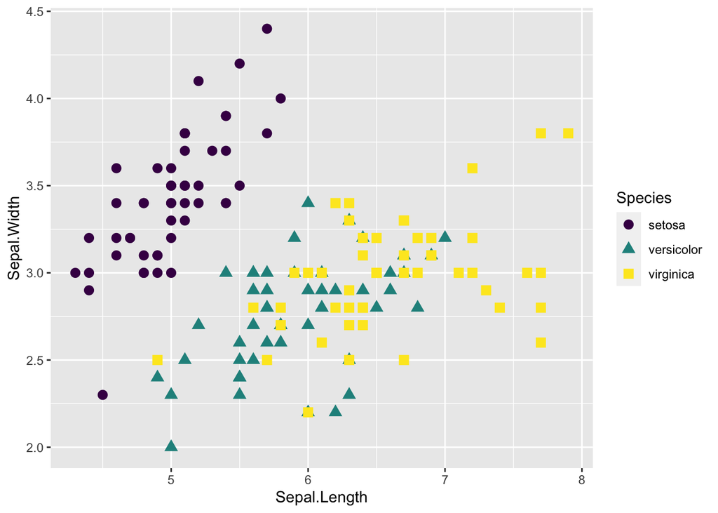

```r
## Here, what I choose to do is to mix color and shape.
ggplot(iris, aes(x=Sepal.Length, y=Sepal.Width,
                 col=Species,
                 shape=Species)) +
  geom_point(size=3) +
  ## Using viridis package here
  scale_color_viridis(discrete=TRUE,option = "D")
```

### Step 3: Find the comfortable themes

The next step that we can do is to figure out what the most fittable themes to match all the hard work we have done above.

#### **Themes from `ggplot2` package**

- In fact, ``ggplot2` package has many cool themes available alreay such as `theme_classic()`, `theme_minimal()` and `theme_bw()`. Another famous theme is the dark theme: `theme_dark()`. Let’s check out some of them.

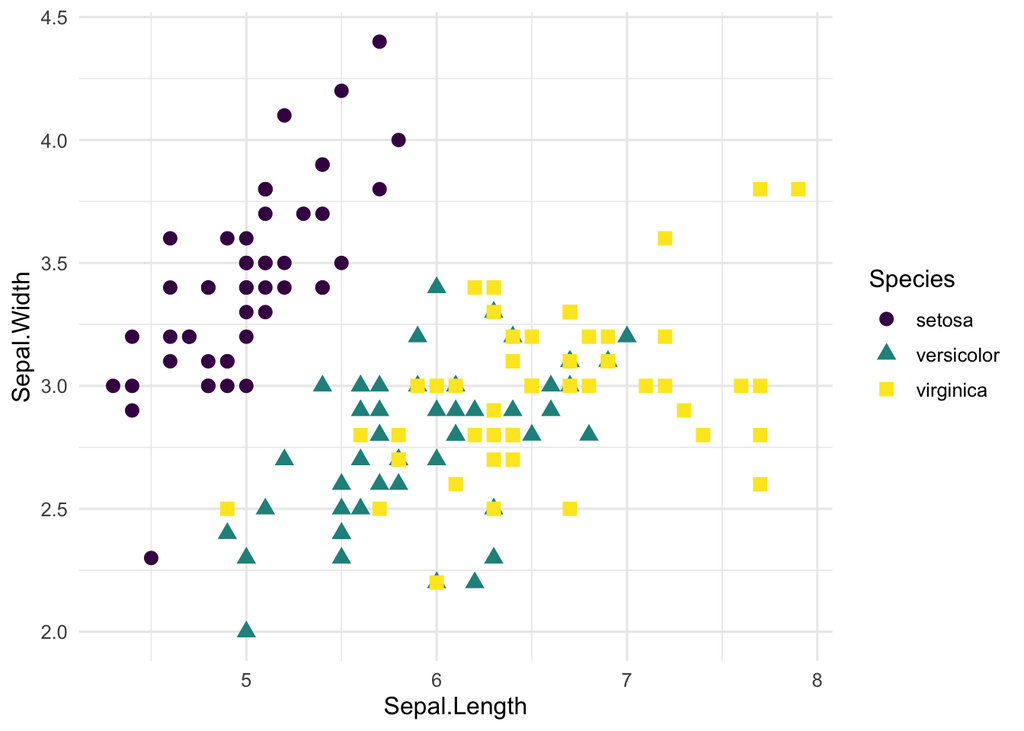

```r
ggplot(iris, aes(x=Sepal.Length, y=Sepal.Width,
                 col=Species,
                 shape=Species)) +
  geom_point(size=3) +
  scale_color_viridis(discrete=TRUE,option = "D") +
  theme_minimal(base_size = 12)
```

#### **Themes from `ggpthemes` package**

- `ggthemes` package is also worth to check out for working any plots (maps,time-series data, and any other plots) that you are working on. `theme_gdocs()`, `theme_tufte()`, and `theme_calc()` all work very well. See [here] (https://yutannihilation.github.io/allYourFigureAreBelongToUs/ggthemes/) to get more cool themes.

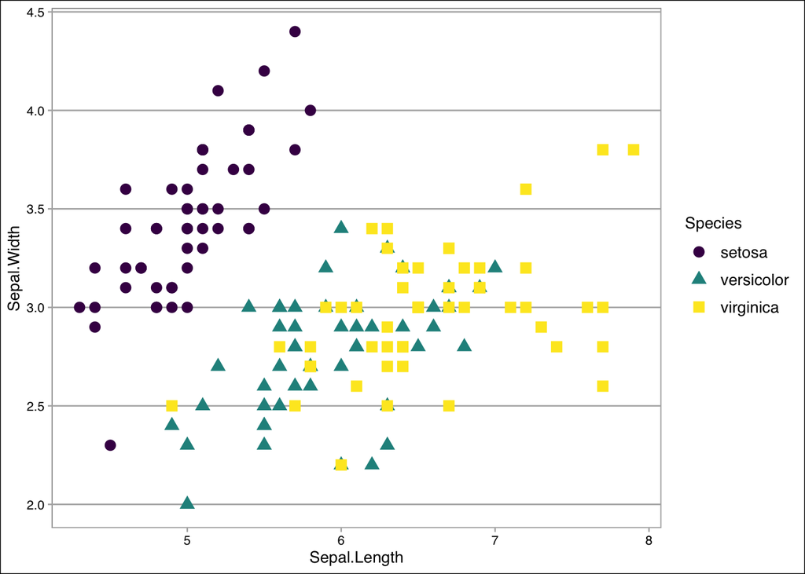

```r
ggplot(iris, aes(x=Sepal.Length, y=Sepal.Width,
                 col=Species,
                 shape=Species)) +
  geom_point(size=3) +
  scale_color_viridis(discrete=TRUE,option = "D") +
  ## Using the theme_calc()
  theme_calc()
```

#### **Create by your own**

- If you do not themes that `ggplot2` and `ggthemes` packages have, don’t worry. You can always create your own style for your themes. Check [here] (https://www.datanovia.com/en/blog/ggplot-themes-gallery/) to desgin your own unique style.

### Step 4: Playing with labs

It is time to label all the useful information to make the plot be clear to your audiences.

#### **Basic Labelling**

- Both `labs()` and `ggtitle()` are great tools to deal with labelling information. In the following code, we provide the example how to use `labs()` to label the all the things that we need. Take a look [here] (https://www.r-graph-gallery.com/289-control-ggplot2-title.html) if you want to learn how to use `ggtitle()`.

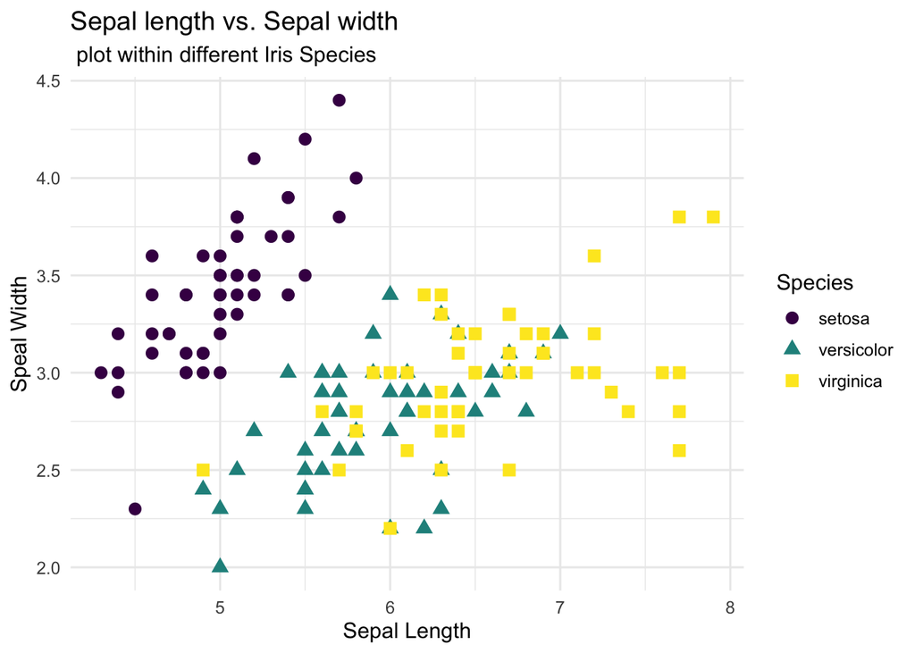

```r
ggplot(iris, aes(x=Sepal.Length, y=Sepal.Width,
                 col=Species,
                 shape=Species)) +
  geom_point(size=3) +
  scale_color_viridis(discrete=TRUE,option = "D") +
  theme_minimal(base_size = 12)+
  ## Where the labelling comes in
  labs(
    ## Tell people what x and y variables are
    x="Sepal Length",
    y="Speal Width",
    ## Title of the plot
    title = "Sepal length vs. Sepal width",
    subtitle = " plot within different Iris Species"
  )
```

#### **Postion and Appearance**

- After the basic labelling, we want to make them nicer by playing around the postion and appearance (text size, color and faces).

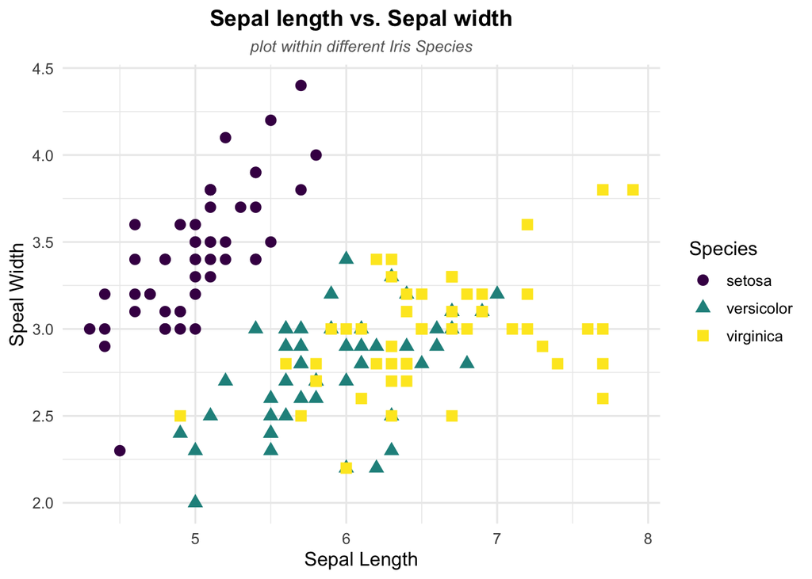

```r
ggplot(iris, aes(x=Sepal.Length, y=Sepal.Width,
                 col=Species,
                 shape=Species)) +
  geom_point(size=3) +
  scale_color_viridis(discrete=TRUE,option = "D") +
  labs(
    x="Sepal Length",
    y="Speal Width",
    title = "Sepal length vs. Sepal width",
    subtitle = "plot within different Iris Species"
  )+
  theme_minimal(base_size = 12) +
  ## Change the title and subtitle position to the center
  theme(plot.title = element_text(hjust = 0.5),
        plot.subtitle = element_text(hjust = 0.5))+
  ## Change the appearance of the title and subtitle
  theme (plot.title = element_text(color = "black", size = 14, face = "bold"),
         plot.subtitle = element_text(color = "grey40",size = 10, face = 'italic')
         )
```

### Step 5: See some patterns

After done with step 4, you should end with a very neat and unquie plot. Let’s end up with this tutorial by checking whether there are some specific patterns in our dataset.

#### **Linear Trend**

- According to the plot, it seems like there exists a linear relationship betwee sepal length and sepal width. Thus, let’s add a linear trend to our scattplot to help readers see the pattern more directly using `geom_smooth()`. Note that the method argument in `geom_smooth()` allows to apply different smoothing method like glm, loess and more. See the [doc](https://ggplot2.tidyverse.org/reference/geom_smooth.html) for more.

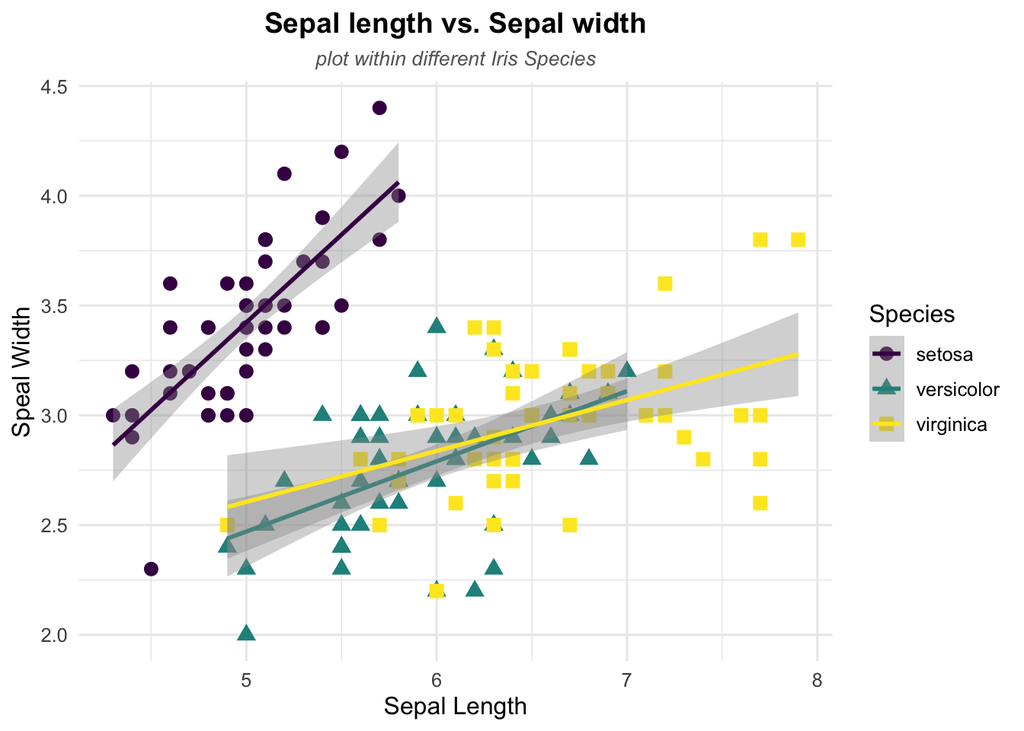

```r
ggplot(iris, aes(x=Sepal.Length, y=Sepal.Width,
                 col=Species,
                 shape=Species)) +
  geom_point(size=3) +
  scale_color_viridis(discrete=TRUE,option = "D") +
  labs(
    x="Sepal Length",
    y="Speal Width",
    title = "Sepal length vs. Sepal width",
    subtitle = "plot within different Iris Species"
  )+
  theme_minimal(base_size = 12) +
  theme(plot.title = element_text(hjust = 0.5),
        plot.subtitle = element_text(hjust = 0.5))+
  theme (plot.title = element_text(color = "black", size = 14, face = "bold"),
         plot.subtitle = element_text(color = "grey40",size = 10, face = 'italic')) +
  ## Where linear trend + confidence interval come in
  geom_smooth(method = 'lm', se=TRUE)
```

## Keep in Mind

- Check [here](https://rstudio.com/wp-content/uploads/2015/03/ggplot2-cheatsheet.pdf) for more data visualization with `ggplot2` package.
- **REMEMBER** always clean your dataset before you try to make scatterplots since in the real world, the dataset is always messier than the `iris` dataset.
- Scatterplots may not work well if the variables that you are interested in are discrete, or if there are a large number of data points.
- **Be more careful** if you have **Date** (which is time-series data) as your x-variable, **Date** can be very tricky in many ways.
- **Google** is always your good friend if you have hard time figuring out your code.

## Also Consider

- Formatting graph legends is important for styling scatterplots. So check [here](https://www.r-graph-gallery.com/239-custom-layout-legend-ggplot2.html) if you want to work with graph legends.
- If you have one of your variables is discrete, instead of scatterplots, you may want to check how to make bar graphs [here](https://lost-stats.github.io/Presentation/bar_graphs.html).
- If you are working with time series visualization with `ggplot2` package, see [here](https://www.r-graph-gallery.com/279-plotting-time-series-with-ggplot2.html) for more help.